# Exploring the BRFSS data

**Research quesion 2:** The main aim of this question is to find out how many hours of sleep is the ideal amount. Since most adults have around 5-12 hours, the ideal number would lie in this range. In the plots given below the least value denotes the ideal hours of sleep required. In many of the plots the least value might be found in the extreme ends ie people who have had an hour of sleep or around 20 hours of sleep. These values should be ignored as we have considered the ratio of the people who have the disease to those who dont and there are not a lot of people whose hours of sleep lie out of the 5-12 hour range. Since due to small numbers the ratio gets affected. Also most of the people who sleep for more than 12 hours a day would be kids and probability of them getting any of the diseases at such a young age is low.

```r
#Variables Used:
#sleptim1: How Much Time Do You Sleep
#toldhi2: Ever Told Blood Cholesterol High
#bphigh4: Ever Told Blood Pressure High
#cvdinfr4: Ever Diagnosed With Heart Attack
#cvdcrhd4: Ever Diagnosed With Angina Or Coronary Heart Disease
#cvdstrk3: Ever Diagnosed With A Stroke
#asthma3: Ever Told Had Asthma
#asthnow: Still Have Asthma
#chcscncr: (Ever Told) You Had Skin Cancer?
#chcocncr: (Ever Told) You Had Any Other Types Of Cancer?
#chccopd1: (Ever Told) You Have (Copd) Chronic Obstructive Pulmonary Disease, Emphysema Or
#havarth3: Told Have Arthritis
#addepev2: Ever Told You Had A Depressive Disorder
#chckidny: (Ever Told) You Have Kidney Disease?
#diabete3: (Ever Told) You Have Diabetes

summary(brfss2013$sleptim1)
```

```
##    Min. 1st Qu.  Median    Mean 3rd Qu.    Max.    NA's
##   0.000   6.000   7.000   7.052   8.000 450.000    7387
```

```r
#To remove the outliers ie sleep time =103 and 450.
brfss2013<-brfss2013[brfss2013$sleptim1<25,]

#For cholesterol

sleep_cholesterol<-brfss2013 %>% group_by(sleptim1,toldhi2) %>% summarise(count=n())
sleep_cholesterol# View the subsetted dataframe
```

```
## # A tibble: 72 x 3
## # Groups:   sleptim1 [?]
##    sleptim1 toldhi2 count
##       <int>  <fctr> <int>
##  1        0      NA     1
##  2        1     Yes    92
##  3        1      No    69
##  4        1      NA    67
##  5        2     Yes   468
##  6        2      No   390
##  7        2      NA   218
##  8        3     Yes  1475
##  9        3      No  1396
## 10        3      NA   625
## # ... with 62 more rows
```

```r
sleep_cholesterol_yes<-na.omit(sleep_cholesterol[sleep_cholesterol$toldhi2=="Yes",])
sleep_cholesterol_yes # To see for how many hour values is the data present for. For all 24 hours.
```

```
## # A tibble: 24 x 3
## # Groups:   sleptim1 [24]
##    sleptim1 toldhi2 count
##       <int>  <fctr> <int>
##  1        1     Yes    92
##  2        2     Yes   468
##  3        3     Yes  1475
##  4        4     Yes  5970
##  5        5     Yes 12934
##  6        6     Yes 39121
##  7        7     Yes 51017
##  8        8     Yes 51990
##  9        9     Yes  9546
## 10       10     Yes  5165
## # ... with 14 more rows
```

```r
sleep_cholesterol_no<-na.omit(sleep_cholesterol[sleep_cholesterol$toldhi2=="No",])
sleep_cholesterol_no # To see for how many hour values is the data present for. For all 24 hours.
```

```
## # A tibble: 24 x 3
## # Groups:   sleptim1 [24]
##    sleptim1 toldhi2 count
##       <int>  <fctr> <int>
##  1        1      No    69
##  2        2      No   390
##  3        3      No  1396
##  4        4      No  5905
##  5        5      No 14952
##  6        6      No 51120
##  7        7      No 72621
##  8        8      No 68992
##  9        9      No 10716
## 10       10      No  5063
## # ... with 14 more rows
```

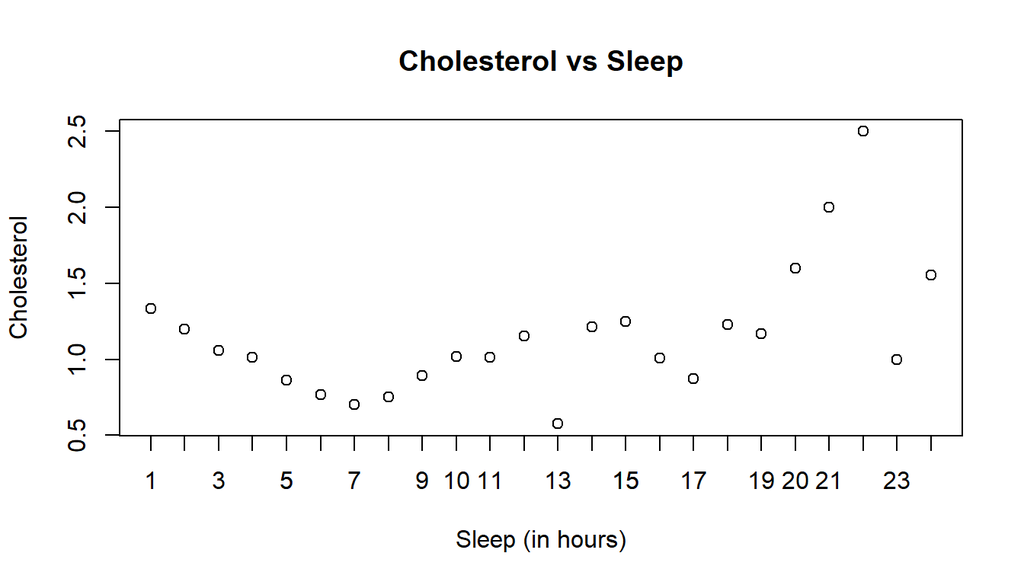

```r
cholesterol_ratio<-sleep_cholesterol_yes$count/sleep_cholesterol_no$count# Calculates the ratio of those who have the disease to those who don't. This is done based on the hours each person has answered they've slept for.
plot(cholesterol_ratio,main="Cholesterol vs Sleep",xlab="Sleep (in hours)", ylab="Cholesterol")# The plot shows that 7 hours of sleep was ideal.
axis(1,c(1:24))
```

```r
#For Blood Pressure
sleep_bp<-brfss2013 %>% group_by(sleptim1,bphigh4) %>% summarise(count=n())
#We Shall only consider the simple yes and no cases for this analysis ignoring the "yes during pregrnancy" and "borderline or prehypertensive" cases.
sleep_bp_yes<-na.omit(sleep_bp[sleep_bp$bphigh4=="Yes",])
sleep_bp_yes # To see for how many hour values is the data present for. For all 24 hours.
```

```
## # A tibble: 24 x 3
## # Groups:   sleptim1 [24]
##    sleptim1 bphigh4 count
##       <int>  <fctr> <int>
##  1        1     Yes   105
##  2        2     Yes   584
##  3        3     Yes  1835
##  4        4     Yes  7028
##  5        5     Yes 14799
##  6        6     Yes 42480
##  7        7     Yes 51340
##  8        8     Yes 56768
##  9        9     Yes 10500
## 10       10     Yes  6164
## # ... with 14 more rows
```

```r
sleep_bp_no<-na.omit(sleep_bp[sleep_bp$bphigh4=="No",])
sleep_bp_no # There is no record of people who have slept for 21 hours and have no bp.
```

```
## # A tibble: 23 x 3
## # Groups:   sleptim1 [23]
##    sleptim1 bphigh4 count
##       <int>  <fctr> <int>
##  1        1      No   118
##  2        2      No   470
##  3        3      No  1585
##  4        4      No  6912
##  5        5      No 17945
##  6        6      No 61470
##  7        7      No 88168
##  8        8      No 81524
##  9        9      No 12850
## 10       10      No  5734
## # ... with 13 more rows
```

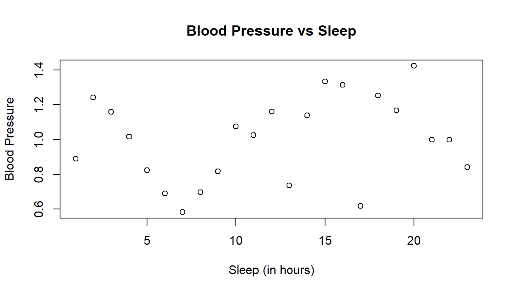

```r
#Hence we shall remove the record of people who have slept for 21 hours and have High Blood Pressure.
sleep_bp_yes<-sleep_bp_yes[sleep_bp_yes$sleptim1!=21,]
bp_ratio<-sleep_bp_yes$count/sleep_bp_no$count# Calculates the ratio of those who have the disease to those who don't. This is done based on the hours each person has answered they've slept for.
plot(bp_ratio,main="Blood Pressure vs Sleep",xlab="Sleep (in hours)", ylab="Blood Pressure")# The plot shows that 7 hours of sleep was ideal.
```

```r
#Heart Attack
sleep_heart<-brfss2013 %>% group_by(sleptim1,cvdinfr4) %>% summarise(count=n())
#We Shall only consider the simple yes and no cases for this analysis ignoring the "yes during pregrnancy" and "borderline or prehypertensive" cases.
sleep_heart_yes<-na.omit(sleep_heart[sleep_heart$cvdinfr4=="Yes",])
sleep_heart_yes
```

```
## # A tibble: 22 x 3
## # Groups:   sleptim1 [22]
##    sleptim1 cvdinfr4 count
##       <int>   <fctr> <int>
##  1        1      Yes    28
##  2        2      Yes   181
##  3        3      Yes   476
##  4        4      Yes  1584
##  5        5      Yes  2462
##  6        6      Yes  5842
##  7        7      Yes  6026
##  8        8      Yes  8151
##  9        9      Yes  1688
## 10       10      Yes  1313
## # ... with 12 more rows
```

```r
sleep_heart_no<-na.omit(sleep_heart[sleep_heart$cvdinfr4=="No",])
sleep_heart_no# There is no record of people who have slept for 19 and 21 hours and have got a heart attack.
```

```
## # A tibble: 24 x 3
## # Groups:   sleptim1 [24]
##    sleptim1 cvdinfr4  count
##       <int>   <fctr>  <int>
##  1        1       No    189
##  2        2       No    879
##  3        3       No   2961
##  4        4       No  12537
##  5        5       No  30745
##  6        6       No  99842
##  7        7       No 135988
##  8        8       No 132283
##  9        9       No  21997
## 10       10       No  10668
## # ... with 14 more rows
```

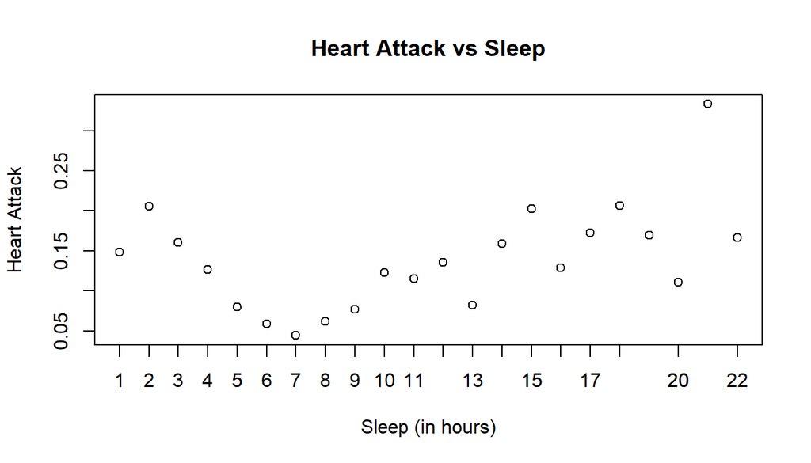

```r
#Hence we shall remove the record of people who have slept for 19 and 21 hours and have not got a heart attack.
sleep_heart_no<-sleep_heart_no[sleep_heart_no$sleptim1!=c(19,21),]
sleep_heart_no<-sleep_heart_no[sleep_heart_no$sleptim1!=21,] # For some reason the previous statement didn't seem to get rid of the record for sleep time=21 hours.
heart_ratio<-sleep_heart_yes$count/sleep_heart_no$count
plot(heart_ratio,main="Heart Attack vs Sleep",xlab="Sleep (in hours)", ylab="Heart Attack")# The plot shows that 7 hours of sleep was ideal.
axis(1,c(1:18,20,22:24))
```

```r
#Coronary Heart Disease
sleep_angina<-brfss2013 %>% group_by(sleptim1,cvdcrhd4) %>% summarise(count=n())
#We Shall only consider the simple yes and no cases for this analysis ignoring the "yes during pregrnancy" and "borderline or prehypertensive" cases.
sleep_angina_yes<-na.omit(sleep_angina[sleep_angina$cvdcrhd4=="Yes",])
sleep_angina_yes
```

```
## # A tibble: 22 x 3
## # Groups:   sleptim1 [22]
##    sleptim1 cvdcrhd4 count
##       <int>   <fctr> <int>
##  1        1      Yes    13
##  2        2      Yes   149
##  3        3      Yes   412
##  4        4      Yes  1487
##  5        5      Yes  2508
##  6        6      Yes  6102
##  7        7      Yes  6128
##  8        8      Yes  7956
##  9        9      Yes  1698
## 10       10      Yes  1282
## # ... with 12 more rows
```

```r
sleep_angina_no<-na.omit(sleep_angina[sleep_angina$cvdcrhd4=="No",])
sleep_angina_no # There is no record of people who have slept for 21 and 23 hours and have coronary heart disease.
```

```
## # A tibble: 24 x 3
## # Groups:   sleptim1 [24]
##    sleptim1 cvdcrhd4  count
##       <int>   <fctr>  <int>
##  1        1       No    209
##  2        2       No    902
##  3        3       No   3011
##  4        4       No  12538
##  5        5       No  30541
##  6        6       No  99234
##  7        7       No 135470
##  8        8       No 132033
##  9        9       No  21874
## 10       10       No  10612
## # ... with 14 more rows
```

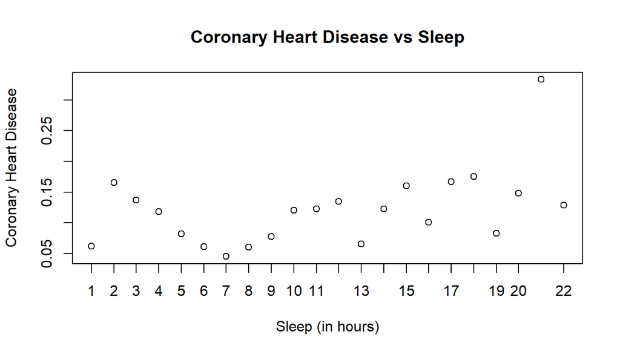

```r
sleep_angina_no<-sleep_angina_no[sleep_angina_no$sleptim1!=c(21,23),]
sleep_angina_no<-sleep_angina_no[sleep_angina_no$sleptim1!=23,]#Hence we shall remove the record of people who have slept for 21 and 23 hours and have not got a coronary heart disease.
angina_ratio<-sleep_angina_yes$count/sleep_angina_no$count
plot(angina_ratio,main="Coronary Heart Disease vs Sleep",xlab="Sleep (in hours)", ylab="Coronary Heart Disease")# The plot shows that 7 hours of sleep was ideal.
axis(1,c(1:20,22,24))
```

```r
#Asthama
sleep_asthama<-brfss2013 %>% group_by(sleptim1,asthma3) %>% summarise(count=n())
#We Shall only consider the simple yes and no cases for this analysis ignoring the "yes during pregrnancy" and "borderline or prehypertensive" cases.
sleep_asthama_yes<-na.omit(sleep_asthama[sleep_asthama$asthma3=="Yes",])
sleep_asthama_yes # No records for sleeptime=23
```

```
## # A tibble: 23 x 3
## # Groups:   sleptim1 [23]
##    sleptim1 asthma3 count
##       <int>  <fctr> <int>
##  1        1     Yes    65
##  2        2     Yes   306
##  3        3     Yes   943
##  4        4     Yes  3491
##  5        5     Yes  6472
##  6        6     Yes 15648
##  7        7     Yes 16640
##  8        8     Yes 16299
##  9        9     Yes  3111
## 10       10     Yes  1826
## # ... with 13 more rows
```

```r
sleep_asthama_no<-na.omit(sleep_asthama[sleep_asthama$asthma3=="No",])
sleep_asthama_no
```

```
## # A tibble: 24 x 3
## # Groups:   sleptim1 [24]
##    sleptim1 asthma3  count
##       <int>  <fctr>  <int>
##  1        1      No    159
##  2        2      No    755
##  3        3      No   2532
##  4        4      No  10707
##  5        5      No  26818
##  6        6      No  90228
##  7        7      No 125476
##  8        8      No 124443
##  9        9      No  20616
## 10       10      No  10235
## # ... with 14 more rows
```

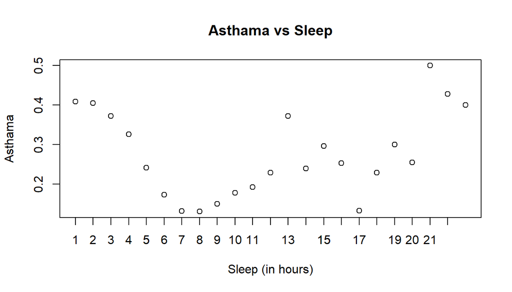

```r
sleep_asthama_no<-sleep_asthama_no[sleep_asthama_no$sleptim1!=23,]
asthama_ratio<-sleep_asthama_yes$count/sleep_asthama_no$count
plot(asthama_ratio,main="Asthama vs Sleep",xlab="Sleep (in hours)", ylab="Asthama")# The plot shows that either 7 or 8 hours of sleep was ideal.
axis(1,c(1:22,24))
```

```r
#Skin Cancer
sleep_sc<-brfss2013 %>% group_by(sleptim1,chcscncr) %>% summarise(count=n())
#We Shall only consider the simple yes and no cases for this analysis ignoring the "yes during pregrnancy" and "borderline or prehypertensive" cases.
sleep_sc_yes<-na.omit(sleep_sc[sleep_sc$chcscncr=="Yes",])
sleep_sc_yes #19,23,24 hours are not present.
```

```
## # A tibble: 21 x 3
## # Groups:   sleptim1 [21]
##    sleptim1 chcscncr count
##       <int>   <fctr> <int>
##  1        1      Yes    18
##  2        2      Yes    89
##  3        3      Yes   267
##  4        4      Yes  1007
##  5        5      Yes  2509
##  6        6      Yes  8431
##  7        7      Yes 13264
##  8        8      Yes 14274
##  9        9      Yes  2858
## 10       10      Yes  1429
## # ... with 11 more rows
```

```r
sleep_sc_no<-na.omit(sleep_sc[sleep_sc$chcscncr=="No",])
sleep_sc_no # There is no record of people who have slept for 23 hours and have no sc.
```

```
## # A tibble: 24 x 3
## # Groups:   sleptim1 [24]
##    sleptim1 chcscncr  count
##       <int>   <fctr>  <int>
##  1        1       No    209
##  2        2       No    978
##  3        3       No   3211
##  4        4       No  13195
##  5        5       No  30827
##  6        6       No  97499
##  7        7       No 128884
##  8        8       No 126508
##  9        9       No  20887
## 10       10       No  10629
## # ... with 14 more rows
```

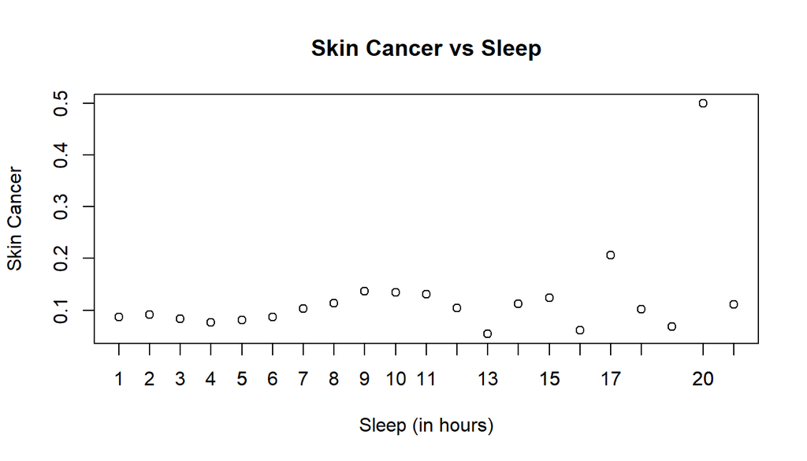

```r
sleep_sc_no<-sleep_sc_no[sleep_sc_no$sleptim1!=c(19,23,24),] #Removing sleeptime=19,23 and 24 records of people who do not have skin cancer.
sc_ratio<-sleep_sc_yes$count/sleep_sc_no$count
plot(sc_ratio,main="Skin Cancer vs Sleep",xlab="Sleep (in hours)", ylab="Skin Cancer") # There is no strong correaltion between your sleep time and skin cancer. What can be inferenced from the data is people who tend to sleep around 9-12 hours a day seemed to have a higher chance of getting skin cancer.
axis(1,c(1:18,20:22))
```

```r
#Other types of Cancer
sleep_cancer<-brfss2013 %>% group_by(sleptim1,chcocncr) %>% summarise(count=n()) %>% filter(sleptim1<25)
#We Shall only consider the simple yes and no cases for this analysis ignoring the "yes during pregrnancy" and "borderline or prehypertensive" cases.
sleep_cancer_yes<-na.omit(sleep_cancer[sleep_cancer$chcocncr=="Yes",])
sleep_cancer_yes
```

```
## # A tibble: 24 x 3
## # Groups:   sleptim1 [24]
##    sleptim1 chcocncr count
##       <int>   <fctr> <int>
##  1        1      Yes    30
##  2        2      Yes   137
##  3        3      Yes   493
##  4        4      Yes  1655
##  5        5      Yes  3260
##  6        6      Yes  9236
##  7        7      Yes 12136
##  8        8      Yes 13911
##  9        9      Yes  2828
## 10       10      Yes  1658
## # ... with 14 more rows
```

```r
sleep_cancer_no<-na.omit(sleep_cancer[sleep_cancer$chcocncr=="No",])
sleep_cancer_no
```

```
## # A tibble: 24 x 3
## # Groups:   sleptim1 [24]
##    sleptim1 chcocncr  count
##       <int>   <fctr>  <int>
##  1        1       No    195
##  2        2       No    931
##  3        3       No   2981
##  4        4       No  12529
##  5        5       No  30066
##  6        6       No  96718
##  7        7       No 130115
##  8        8       No 126945
##  9        9       No  20920
## 10       10       No  10410
## # ... with 14 more rows
```

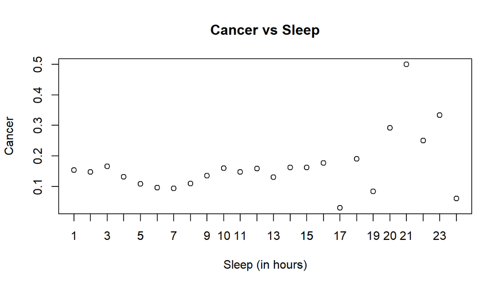

```r
cancer_ratio<-sleep_cancer_yes$count/sleep_cancer_no$count
plot(cancer_ratio ,main="Cancer vs Sleep",xlab="Sleep (in hours)", ylab="Cancer") # The plot shows that either 6 or 7 hours of sleep was ideal.
axis(1,c(1:24))
```

```r
#Chronic Pulmonary Disease
sleep_cpd<-brfss2013 %>% group_by(sleptim1,chccopd1) %>% summarise(count=n()) %>% filter(sleptim1<25)
#We Shall only consider the simple yes and no cases for this analysis ignoring the "yes during pregrnancy" and "borderline or prehypertensive" cases.
sleep_cpd_yes<-na.omit(sleep_cpd[sleep_cpd$chccopd1=="Yes",])
sleep_cpd_yes #19,23,24 hours are not present.
```

```
## # A tibble: 22 x 3
## # Groups:   sleptim1 [22]
##    sleptim1 chccopd1 count
##       <int>   <fctr> <int>
##  1        1      Yes    47
##  2        2      Yes   249
##  3        3      Yes   743
##  4        4      Yes  2848
##  5        5      Yes  4288
##  6        6      Yes  9239
##  7        7      Yes  7727
##  8        8      Yes  9706
##  9        9      Yes  2055
## 10       10      Yes  1586
## # ... with 12 more rows
```

```r
sleep_cpd_no<-na.omit(sleep_cpd[sleep_cpd$chccopd1=="No",])
sleep_cpd_no # There is no record of people who have slept for 23 hours and have no cpd.
```

```
## # A tibble: 24 x 3
## # Groups:   sleptim1 [24]
##    sleptim1 chccopd1  count
##       <int>   <fctr>  <int>
##  1        1       No    175
##  2        2       No    810
##  3        3       No   2725
##  4        4       No  11240
##  5        5       No  28914
##  6        6       No  96393
##  7        7       No 134186
##  8        8       No 130762
##  9        9       No  21623
## 10       10       No  10422
## # ... with 14 more rows
```

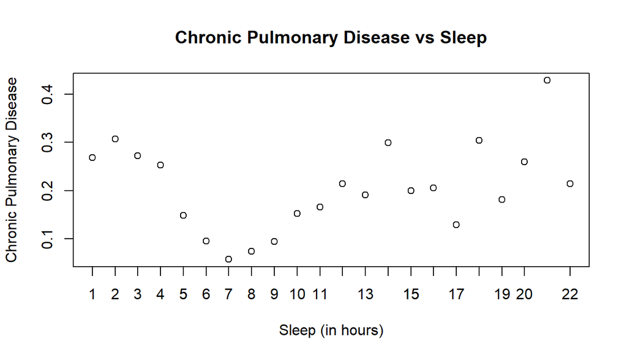

```r
sleep_cpd_no<-sleep_cpd_no[sleep_cpd_no$sleptim1!=c(21,23),]
sleep_cpd_no<-sleep_cpd_no[sleep_cpd_no$sleptim1!=23,]#Hence we shall remove the record of people who have slept for 21 and 23 hours and have not got a chronic pulmonary disease
cpd_ratio<-sleep_cpd_yes$count/sleep_cpd_no$count
plot(cpd_ratio,main="Chronic Pulmonary Disease vs Sleep",xlab="Sleep (in hours)", ylab="Chronic Pulmonary Disease") #This plot resembles most of the other plots indicating that 7 hours of sleep was the ideal amount.
axis(1,at=c(1:20,22,24))
```

```r
#Arthritis
sleep_arthritis<-brfss2013 %>% group_by(sleptim1,havarth3) %>% summarise(count=n()) %>% filter(sleptim1<25)
#We Shall only consider the simple yes and no cases for this analysis ignoring the "yes during pregrnancy" and "borderline or prehypertensive" cases.
sleep_arthritis_yes<-na.omit(sleep_arthritis[sleep_arthritis$havarth3=="Yes",])
sleep_arthritis_yes
```

```
## # A tibble: 24 x 3
## # Groups:   sleptim1 [24]
##    sleptim1 havarth3 count
##       <int>   <fctr> <int>
##  1        1      Yes   102
##  2        2      Yes   617
##  3        3      Yes  1925
##  4        4      Yes  7305
##  5        5      Yes 13944
##  6        6      Yes 36373
##  7        7      Yes 40752
##  8        8      Yes 44056
##  9        9      Yes  8503
## 10       10      Yes  5157
## # ... with 14 more rows
```

```r
sleep_arthritis_yes<-sleep_arthritis_yes[sleep_arthritis_yes$sleptim1!=21,] #we shall remove the record of people who have slept for 21 hours and have got arthiritis.
sleep_arthritis_no<-na.omit(sleep_arthritis[sleep_arthritis$havarth3=="No",])
sleep_arthritis_no# There is no record of people who have slept for 21 hours and have no arthritis.
```

```
## # A tibble: 23 x 3
## # Groups:   sleptim1 [23]
##    sleptim1 havarth3  count
##       <int>   <fctr>  <int>
##  1        1       No    121
##  2        2       No    441
##  3        3       No   1533
##  4        4       No   6839
##  5        5       No  19256
##  6        6       No  69259
##  7        7       No 100999
##  8        8       No  96265
##  9        9       No  15165
## 10       10       No   6871
## # ... with 13 more rows
```

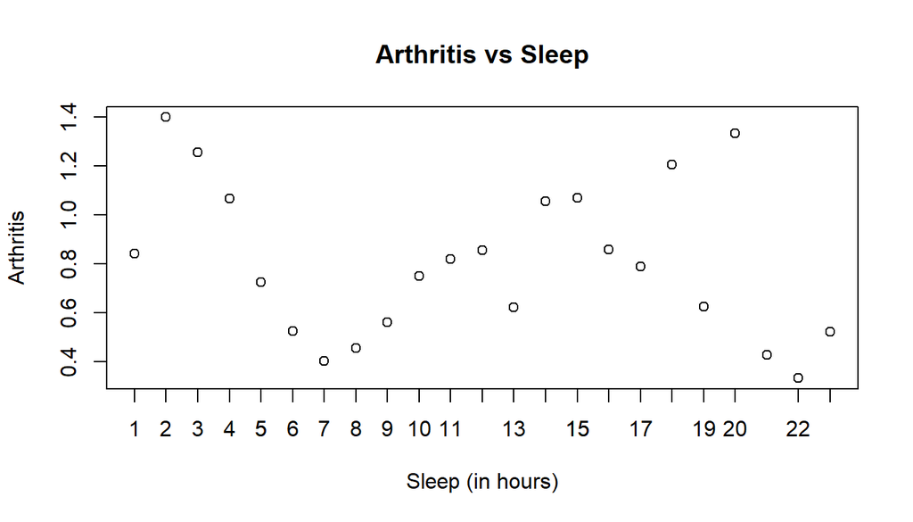

```r
arthritis_ratio<-sleep_arthritis_yes$count/sleep_arthritis_no$count
plot(arthritis_ratio,main="Arthritis vs Sleep",xlab="Sleep (in hours)", ylab="Arthritis") #This plot resembles most of the other plots indicating that 7 hours of sleep was the ideal amount.
axis(1,at=c(1:20,22,23,24))
```

```r
#Depressive Disorder
sleep_dep<-brfss2013 %>% group_by(sleptim1,addepev2) %>% summarise(count=n()) %>% filter(sleptim1<25)
#We Shall only consider the simple yes and no cases for this analysis ignoring the "yes during pregrnancy" and "borderline or prehypertensive" cases.
sleep_dep_yes<-na.omit(sleep_dep[sleep_dep$addepev2=="Yes",])
sleep_dep_yes #19,23,24 hours are not present.
```

```
## # A tibble: 24 x 3
## # Groups:   sleptim1 [24]
##    sleptim1 addepev2 count
##       <int>   <fctr> <int>
##  1        1      Yes   103
##  2        2      Yes   558
##  3        3      Yes  1706
##  4        4      Yes  5820
##  5        5      Yes  9641
##  6        6      Yes 21552
##  7        7      Yes 20757
##  8        8      Yes 22653
##  9        9      Yes  5196
## 10       10      Yes  3613
## # ... with 14 more rows
```

```r
sleep_dep_no<-na.omit(sleep_dep[sleep_dep$addepev2=="No",])
sleep_dep_no# There is no record of people who have slept for 23 hours and have no dep.
```

```
## # A tibble: 24 x 3
## # Groups:   sleptim1 [24]
##    sleptim1 addepev2  count
##       <int>   <fctr>  <int>
##  1        1       No    120
##  2        2       No    501
##  3        3       No   1757
##  4        4       No   8319
##  5        5       No  23578
##  6        6       No  84171
##  7        7       No 121240
##  8        8       No 117906
##  9        9       No  18513
## 10       10       No   8429
## # ... with 14 more rows
```

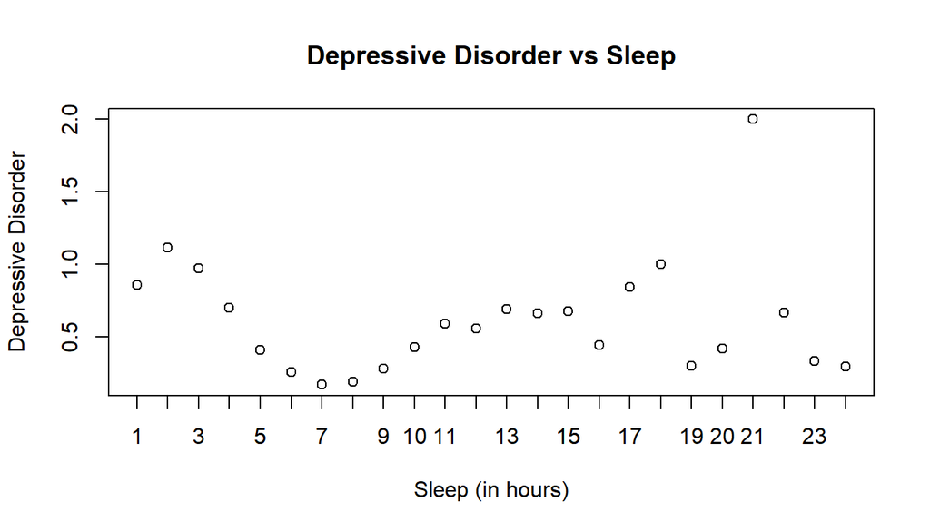

```r
dep_ratio<-sleep_dep_yes$count/sleep_dep_no$count
plot(dep_ratio,main="Depressive Disorder vs Sleep",xlab="Sleep (in hours)", ylab="Depressive Disorder") #This plot resembles most of the other plots indicating that 7 hours of sleep was the ideal amount.
axis(1,at=c(1:24))
```

```r
#Kidney Disease
sleep_kid<-brfss2013 %>% group_by(sleptim1,chckidny) %>% summarise(count=n()) %>% filter(sleptim1<25)
#We Shall only consider the simple yes and no cases for this analysis ignoring the "yes during pregrnancy" and "borderline or prehypertensive" cases.
sleep_kid_yes<-na.omit(sleep_kid[sleep_kid$chckidny=="Yes",])
sleep_kid_yes #19,23,24 hours are not present.
```

```
## # A tibble: 23 x 3
## # Groups:   sleptim1 [23]
##    sleptim1 chckidny count
##       <int>   <fctr> <int>
##  1        1      Yes    19
##  2        2      Yes    71
##  3        3      Yes   255
##  4        4      Yes   846
##  5        5      Yes  1475
##  6        6      Yes  3309
##  7        7      Yes  3221
##  8        8      Yes  4261
##  9        9      Yes   931
## 10       10      Yes   705
## # ... with 13 more rows
```

```r
sleep_kid_no<-na.omit(sleep_kid[sleep_kid$chckidny=="No",])
sleep_kid_no # There is no record of people who have slept for 23 hours and have no kid.
```

```
## # A tibble: 24 x 3
## # Groups:   sleptim1 [24]
##    sleptim1 chckidny  count
##       <int>   <fctr>  <int>
##  1        1       No    205
##  2        2       No    990
##  3        3       No   3209
##  4        4       No  13317
##  5        5       No  31799
##  6        6       No 102565
##  7        7       No 138907
##  8        8       No 136465
##  9        9       No  22776
## 10       10       No  11327
## # ... with 14 more rows
```

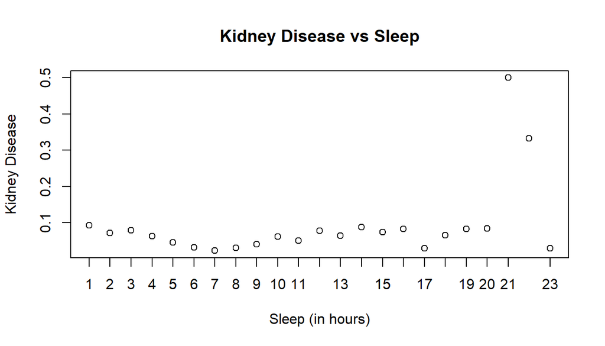

```r
sleep_kid_no<-sleep_kid_no[sleep_kid_no$sleptim1!=22,]
kid_ratio<-sleep_kid_yes$count/sleep_kid_no$count
plot(kid_ratio,main="Kidney Disease vs Sleep",xlab="Sleep (in hours)", ylab="Kidney Disease")
axis(1,c(1:21,23,24))
```

```r
#Diabetes
sleep_diabetes<-brfss2013 %>% group_by(sleptim1,diabete3) %>% summarise(count=n()) %>% filter(sleptim1<25)
#We Shall only consider the simple yes and no cases for this analysis ignoring the "yes during pregrnancy" and "borderline or prehypertensive" cases.
sleep_diabetes_yes<-na.omit(sleep_diabetes[sleep_diabetes$diabete3=="Yes",])
sleep_diabetes_yes #19,23,24 hours are not present.
```

```
## # A tibble: 24 x 3
## # Groups:   sleptim1 [24]
##    sleptim1 diabete3 count
##       <int>   <fctr> <int>
##  1        1      Yes    49
##  2        2      Yes   251
##  3        3      Yes   749
##  4        4      Yes  2783
##  5        5      Yes  5272
##  6        6      Yes 13282
##  7        7      Yes 13574
##  8        8      Yes 17440
##  9        9      Yes  3379
## 10       10      Yes  2512
## # ... with 14 more rows
```

```r
sleep_diabetes_no<-na.omit(sleep_diabetes[sleep_diabetes$diabete3=="No",])
sleep_diabetes_no # There is no record of people who have slept for 23 hours and have no diabetes.
```

```
## # A tibble: 24 x 3
## # Groups:   sleptim1 [24]
##    sleptim1 diabete3  count
##       <int>   <fctr>  <int>
##  1        1       No    170
##  2        2       No    766
##  3        3       No   2588
##  4        4       No  10908
##  5        5       No  27045
##  6        6       No  89692
##  7        7       No 125286
##  8        8       No 120013
##  9        9       No  19754
## 10       10       No   9185
## # ... with 14 more rows
```

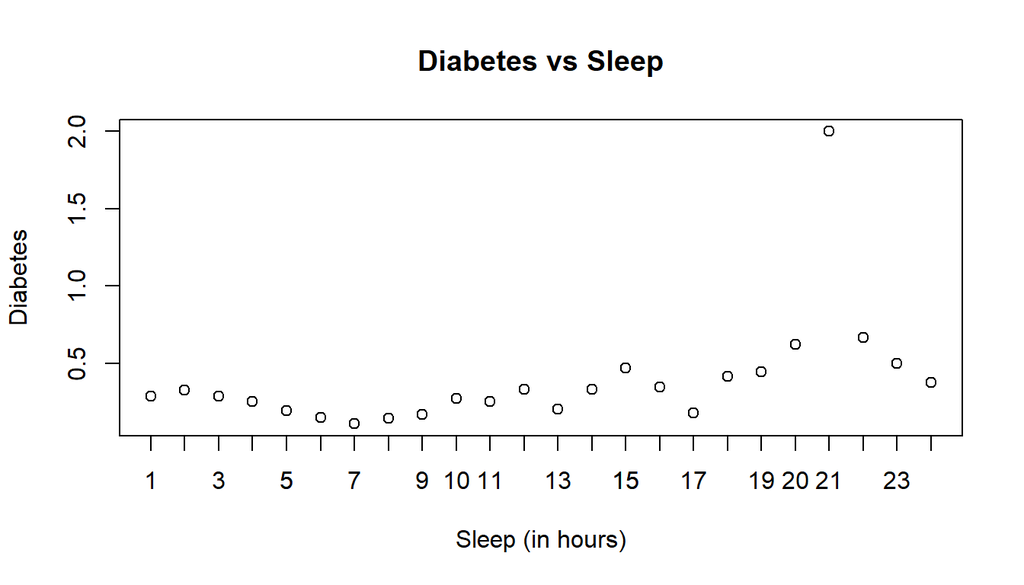

```r
diabetes_ratio<-sleep_diabetes_yes$count/sleep_diabetes_no$count
plot(diabetes_ratio,main="Diabetes vs Sleep",xlab="Sleep (in hours)", ylab="Diabetes")
axis(1,c(1:24))
```

Conclusion: From the data it was found out that the ideal sleep time is 7 hours.

**Research quesion 3:** The smoke100 variable has the least number of missing values when compared to rest of the variables containing data about tobacco use. Hence this will be our primary variable.

```r
#Variables used:
#_state: State Fips Code
#smoke100: Smoked At Least 100 Cigarettes
#usenow3: Use Of Smokeless Tobacco Products

summary(brfss2013$smoke100) # There are 21734 missing variables
```

```
##    Yes     No   NA's
## 211970 258069  21734
```

```r
#We shall try to impute values for some of the missing variables using data from the other variables that contain data about tobacco use(in particular usenow3)

brfss2013 %>% group_by(is.na(smoke100),usenow3) %>% summarise(count=n())
```

```
## # A tibble: 8 x 3
## # Groups:   is.na(smoke100) [?]
##   `is.na(smoke100)`    usenow3  count
##               <lgl>     <fctr>  <int>
## 1             FALSE  Every day   8587
## 2             FALSE  Some days   6729
## 3             FALSE Not at all 453658
## 4             FALSE         NA   1065
## 5              TRUE  Every day     37
## 6              TRUE  Some days     37
## 7              TRUE Not at all   1797
## 8              TRUE         NA  19863
```

```r
#The above command shows that there are 1797 people who don't use smokeless tobacco products as well(these can be encoded as 'No' in the smoke100 variable). Hence in place of the missing variables in the 'smoke100' variable, they can be imputed with the value and 'No'.

tobacco<-brfss2013
tobacco$smoke100<-factor(tobacco$smoke100)

#Encode the missing variables of smoke100 as No which have corresponding values as 'Not at all' in the variable 'usenow3'.
tobacco$smoke100<-ifelse(is.na(tobacco$smoke100) & tobacco$usenow3=="Not at all","No",tobacco$smoke100)

#For clearer view rename factors
tobacco$smoke100[tobacco$smoke100==2]<-"No"
tobacco$smoke100[tobacco$smoke100==1]<-"Yes"

#Finding the count of tobacco users by their respective state.
tobacco_use<-tobacco %>% group_by(X_state,smoke100) %>% summarise(count=n())
tobacco_use<-na.omit(tobacco_use)#removing missing instances.

tobacco_use
```

```
## # A tibble: 106 x 3
## # Groups:   X_state [53]
##       X_state smoke100 count
##        <fctr>    <chr> <int>
##  1    Alabama       No  3428
##  2    Alabama      Yes  2801
##  3     Alaska       No  2234
##  4     Alaska      Yes  2230
##  5    Arizona       No  2139
##  6    Arizona      Yes  1944
##  7   Arkansas       No  2600
##  8   Arkansas      Yes  2440
##  9 California       No  6556
## 10 California      Yes  4041
## # ... with 96 more rows
```

```r
#Converting state names into lower case.
tobacco_use$X_state<-tolower(tobacco_use$X_state)

#loading geospatial usa map data
states<-map_data("state")

#converting state names into lower case
tobacco$X_state<-tolower(tobacco$X_state)

#renaming column names of tobacco_use dataframe.
colnames(tobacco_use)<-c("region","smoke100","count")

#subsetting only people who have admitted to using tobacco
tobacco_use_yes<-tobacco_use[tobacco_use$smoke100=="Yes",]
#Finding out the percentage of tobacco users per state.
tobacco_use_yes$percent<-round((tobacco_use_yes$count/sum(tobacco_use_yes$count))*100,2)

tobacco_use_yes
```

```
## # A tibble: 53 x 4
##                  region smoke100 count percent
##                   <chr>    <chr> <int>   <dbl>
##  1              alabama      Yes  2801    1.32
##  2               alaska      Yes  2230    1.05
##  3              arizona      Yes  1944    0.92
##  4             arkansas      Yes  2440    1.15
##  5           california      Yes  4041    1.91
##  6             colorado      Yes  5609    2.65
##  7          connecticut      Yes  3404    1.61
##  8             delaware      Yes  2336    1.10
##  9 district of columbia      Yes  1963    0.93
## 10              florida      Yes 16147    7.62
## # ... with 43 more rows
```

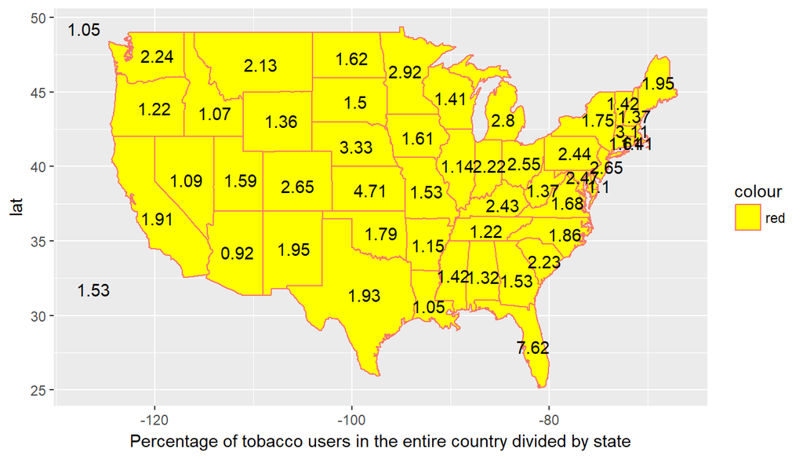

```r
#merging the geospatial data with certain columns of the dataframe tobacco_use_yes
merge_yes<-merge(states,tobacco_use_yes[,c(1,3,4)],by="region")

#finding out the center of each state and then merge it with the tobacco_use_yes.
state_names<-data.frame(region=tolower(state.name), long=state.center$x, lat=state.center$y)
state_names_yes<-merge(state_names, tobacco_use_yes, by="region")

#Visualizing the data of tobacco users.
ggplot(merge_yes, aes(long, lat)) + geom_polygon(aes(group=group, fill=percent,color="red"),fill="yellow") + geom_text(data=state_names_yes, aes(long, lat, label=percent))+ xlab("Percentage of tobacco users in the entire country divided by state")
```

```r
#To visualize the data of people who have said they do not use tobacco products

#subsetting only people who have admitted not to using tobacco
tobacco_use_no<-tobacco_use[tobacco_use$smoke100=="No",]
#Finding out the percentage of people who do not use tobacco per state.
tobacco_use_no$percent<-round((tobacco_use_no$count/sum(tobacco_use_no$count))*100,2)
tobacco_use_no
```

```
## # A tibble: 53 x 4
##                  region smoke100 count percent
##                   <chr>    <chr> <int>   <dbl>
##  1              alabama       No  3428    1.32
##  2               alaska       No  2234    0.86
##  3              arizona       No  2139    0.82
##  4             arkansas       No  2600    1.00
##  5           california       No  6556    2.52
##  6             colorado       No  7061    2.72
##  7          connecticut       No  4028    1.55
##  8             delaware       No  2680    1.03
##  9 district of columbia       No  2701    1.04
## 10              florida       No 16058    6.18
## # ... with 43 more rows
```

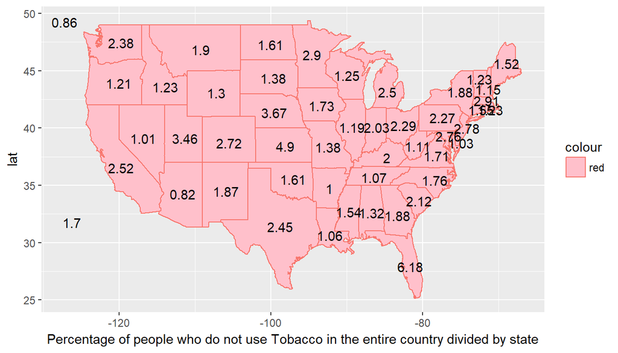

```r
#merging the geospatial data with certain columns of the dataframe tobacco_use_no
merge_no<-merge(states,tobacco_use_no[,c(1,3,4)],by="region")

#finding out the center of each state and then merge it with the tobacco_use_no.
state_names_no<-merge(state_names, tobacco_use_no, by="region")

#Visualizing the data of people who do not use tobacco.
ggplot(merge_no, aes(long, lat)) + geom_polygon(aes(group=group, fill=percent,color="red"),fill="pink") + geom_text(data=state_names_no, aes(long, lat, label=percent))+xlab("Percentage of people who do not use Tobacco in the entire country divided by state")
```

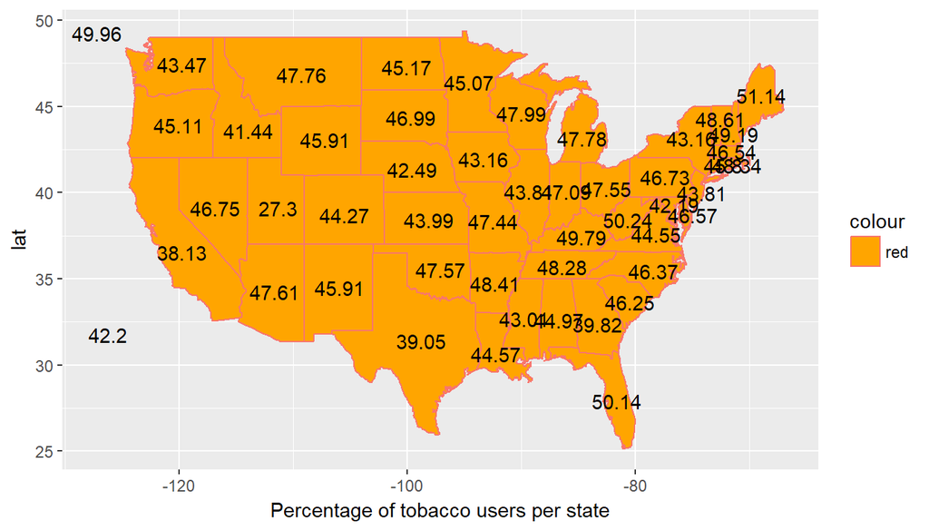

```r
#In the given data if we want to visualize the percentage of tobacco users per state. ie =tobacco users per state/total number of people belonging to that state.
tobacco_use$total<-0
for(i in seq(1,106,2)){
  tobacco_use$total[i]<-tobacco_use$count[i]+tobacco_use$count[i+1]
  tobacco_use$total[i+1]<-tobacco_use$count[i]+tobacco_use$count[i+1]
}

tobacco_use$percent<-round((tobacco_use$count/tobacco_use$total)*100,2)

tobacco_use_total<-tobacco_use[tobacco_use$smoke100=="Yes",]

#merging the geospatial data with certain columns of the dataframe tobacco_use_total
merge_total<-merge(states,tobacco_use_total[,c(1,3,5)],by="region")

#finding out the center of each state and then merge it with the tobacco_use_total.
state_names_total<-merge(state_names, tobacco_use_total, by="region")

#Visualizing the tobacco users per state.
ggplot(merge_total, aes(long, lat)) + geom_polygon(aes(group=group, fill=percent,colour="red"),fill="orange") + geom_text(data=state_names_total, aes(long, lat, label=percent))+xlab("Percentage of tobacco users per state")
```